# Part II - (Loan Data from Prosper)

## by (Jennifer Nwamu)

## Investigation Overview

> The goal of this presentation is to find out factors that affect the loan status and APR of borrowers based on various features of the loan such as demographics of borrowers, Loan amount, Ratings(Credit and Prosper), Propser scores and reason of taking the Loan. This would help the company to predict the future behavior of loan borrowers based on these set of features.

## Dataset Overview

> This is a clean dataset containing 113,781 loan entries with 30 features such as loan amout, employment status, borrower APR, Loan Status amongst others which was gotten from an intial dataset from prosper loan.

## Distribution of Loan status and Borrower's APR

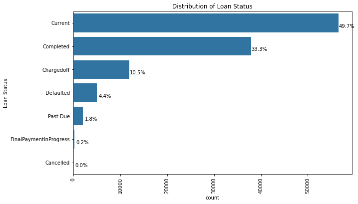

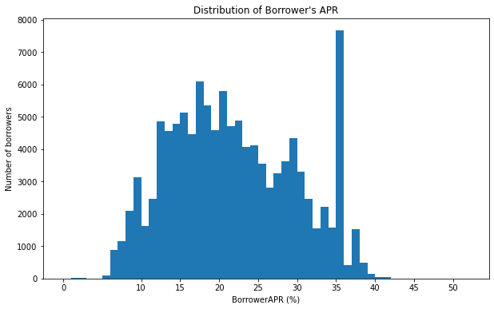

## Effect of Rating/Prosper Score and Loan amount on Borrower's APR and Loan Status

Having seen the distribution of our key features, we now move to have an insight into the relationship between the Loan amount and Rating/Prosper Score on Loan status and Borrower's APR.

`Figure A` A point plot which shows that there is a negative effect of rating on the borrower's APR. This indicates that a borrower with a **low rating** is mostly likely to be given a **higher APR** than those with a **higher rating** who recieves a **lower APR**. This is not suprising as a good rating should be rewarded with a lesser APR.

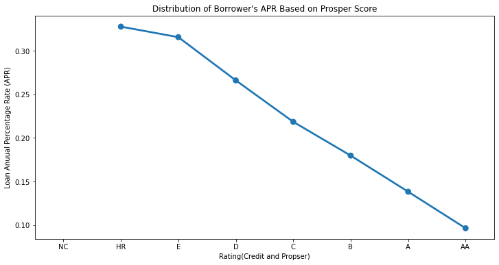

`Figure B`: A point plot that shows Prosper score has a relationship with loan status, borrowers with **higher prosper score** tend to **complete** their loans.

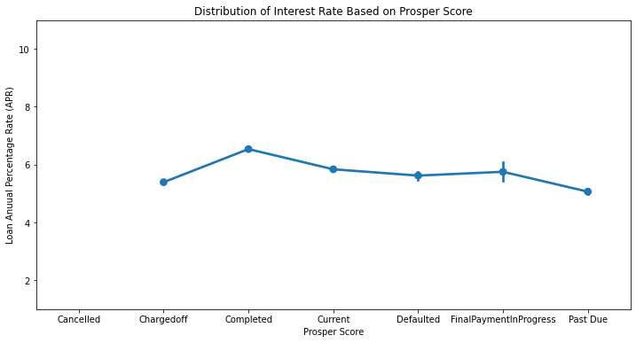

`Figure C`: A scattered plot shows that majority of borrowers who take loans on **higher amount** usually have **good ratings** as well as have a **lower APR**.

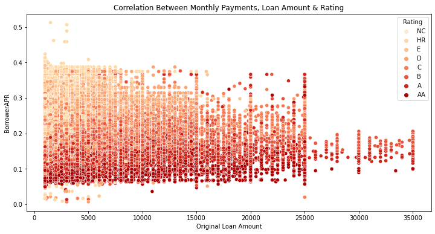

`Figure D`, A box plots shows Majority of borrower's having **high APR** along side a **high loan amount** tend to be **past due stages** in paying their loans compared to others.

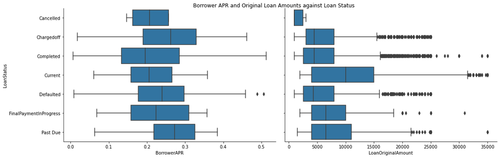

## Examining the effect of Employment status on Borrower APR and Loan Status

Let us find out what effect the employment status of a borrower has on the Annual Percentage Rate and status of the loan.

> From the plots below, there is a clear relationship which shows that borrower's that are **unemployed** gets a **higher APR** this is not suprising as they are seem to be high risk .

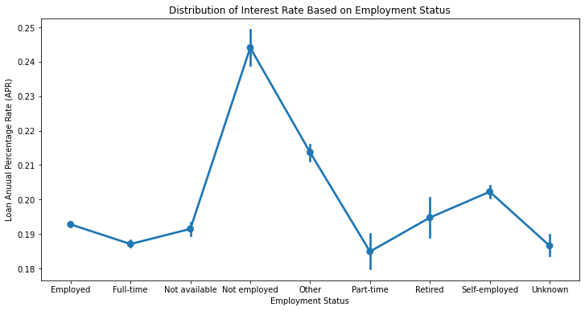

Heat Map to check the effect employment status has over the status of a loan.

> There seem to be a surprising insights that shows that borrowers that are in **full-time** tend to have a *defaulted loan* as well as a higher chance of *completing* their loans. Those **employed** have a higher chance of having their loans *past-due*.

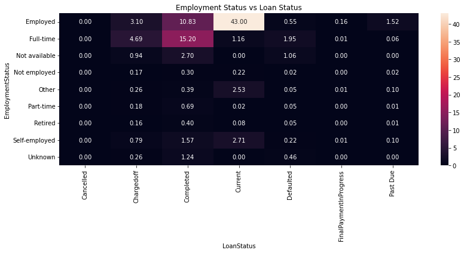

## Examining the effect of Listing Category on Borrower APR and Loan Status

Lastly, we would like to see the impact the reason for borrowing (Listing Category) have on the borrower's APR and status.

> The Plots below shows that the **top reason** for borrowers is due to **debt consolidation**. It was observed that those who indicated **cosmetic procedures** had a higher **borrower APR** in comparison to other reasons. It was also shown that loans taken by borrowers who chose **not available** as reason for borrowing had a **high defaulted and charged off** rate. There is need to properly identify this category of borrowers and capture most reasons to be able to use this factor to predict the outcome of a loan status.

A point plot showing Relationship between Listing Category and Borrower APR

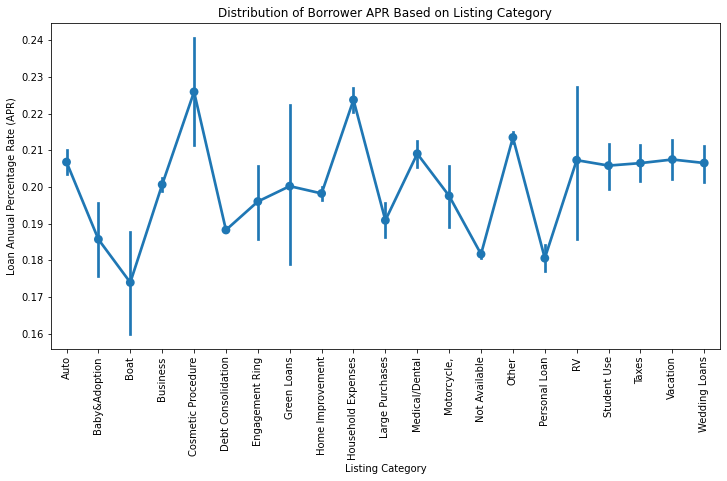

A heat map showing the Relationship between Listing Category and Loan Status

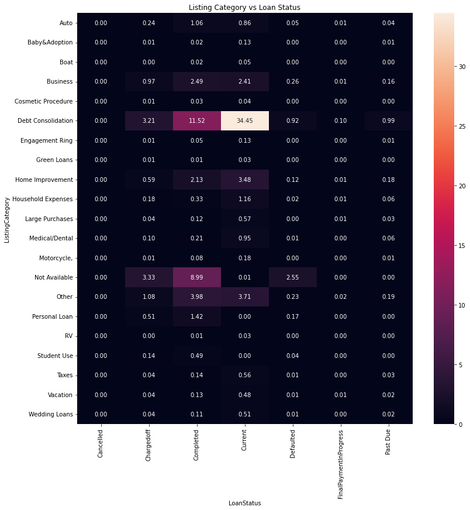